# Practical Machine Learning Project

April 24, 2015

In order to predict the manner in which the barbell lifts were done, we will use the caret package. First, the training data set is loaded in. After inspecting the training data, it is apparent that there are a number of variables with missing data.

```r
library(caret)
training_data <- read.table(file='pml-training.csv', header=T, sep=",", na.strings="NA")
summary(training_data)
```

[output not shown]

[output cut: 289 more lines]

```
##  Min.   : -8.09   Min.   :-498.0   Min.   :-632    Min.   :-446.0
##  1st Qu.: -0.18   1st Qu.:-178.0   1st Qu.:  57    1st Qu.:-182.0
##  Median :  0.08   Median : -57.0   Median : 201    Median : -39.0
##  Mean   :  0.15   Mean   : -61.7   Mean   : 164    Mean   : -55.3
##  3rd Qu.:  0.49   3rd Qu.:  76.0   3rd Qu.: 312    3rd Qu.:  26.0
##  Max.   :231.00   Max.   : 477.0   Max.   : 923    Max.   : 291.0
##
##  magnet_forearm_x magnet_forearm_y magnet_forearm_z classe
##  Min.   :-1280    Min.   :-896     Min.   :-973     A:5580
##  1st Qu.: -616    1st Qu.:   2     1st Qu.: 191     B:3797
##  Median : -378    Median : 591     Median : 511     C:3422
##  Mean   : -313    Mean   : 380     Mean   : 394     D:3216
##  3rd Qu.:  -73    3rd Qu.: 737     3rd Qu.: 653     E:3607
##  Max.   :  672    Max.   :1480     Max.   :1090
##
```

To speed the efficiency of the machine learning algortihm, and because many algorithms cannot handle missing data, all variables in which more than 50% of the observations were missing are removed. In addition, two variables that are not measurements taken during the excercise, the observation identifier and the user name, and therefore should not be utilized in the prediction are removed.

```r
training_NA <- training_data[,colSums(is.na(training_data))<nrow(training_data)*.5]
training_complete <- training_NA[,colSums(training_NA=="")<nrow(training_NA)*.5]
training_complete <- training_complete[,3:ncol(training_complete)]
```

Because we are not provided testing data separate from the final validation data, we split the testing data into a training set and a testing set; 80% of the data is used for the training set and 20% of the data is used for the testing set.

```r
inTrain <- createDataPartition(training_complete$classe, p=.8, list=FALSE)
train_set <- training_complete[inTrain,]
test_set <- training_complete[-inTrain,]
```

Because random forest often peforms well in prediction, we will attempt a Random Forest model using the train function in the caret package. The train function has the additional advantage of performing boostraping when building the Random Forest trees.

```r
RF_model <- train(classe~., data=train_set, method="rf")
RF_model
```

```
## Random Forest
##
## 15699 samples
##    57 predictor
##     5 classes: 'A', 'B', 'C', 'D', 'E'
##
## No pre-processing
## Resampling: Bootstrapped (25 reps)
##
## Summary of sample sizes: 15699, 15699, 15699, 15699, 15699, 15699, ...
##
## Resampling results across tuning parameters:
##
##   mtry  Accuracy  Kappa   Accuracy SD  Kappa SD
##    2    0.9909    0.9885  0.0013205    0.0016710
##   38    0.9986    0.9983  0.0006126    0.0007751
##   75    0.9972    0.9965  0.0013020    0.0016454
##
## Accuracy was used to select the optimal model using  the largest value.
## The final value used for the model was mtry = 38.
```

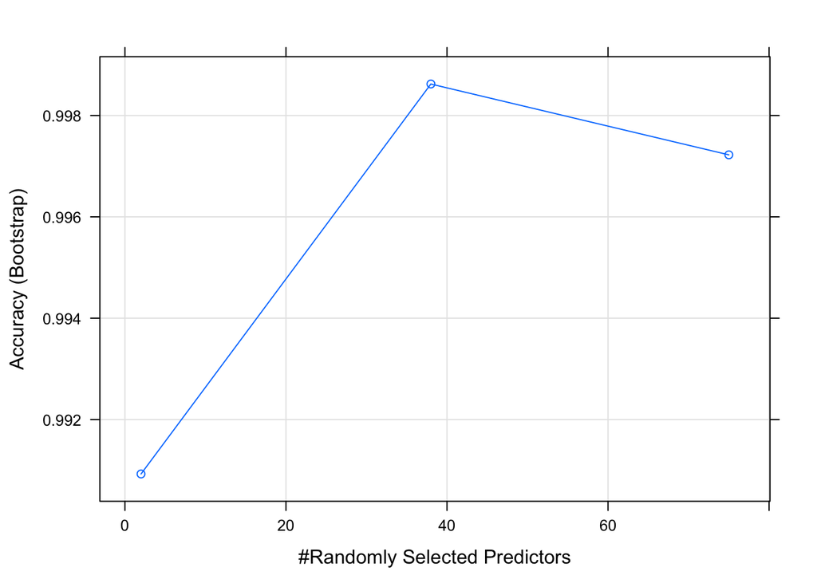

```r
plot(RF_model)
```

Based on the estimated out of sample error rate, Random Forest seems to have been a good choice for a model, so we will see how the model performs with the data that was set aside as the testing data.

```r
RF_predict <- predict(RF_model, test_set)
```

Comparing the predictions to the true values, we see that the model also performs well on the test data.

```r
table(RF_predict, test_set$classe)
```

```
##
## RF_predict    A    B    C    D    E
##          A 1116    0    0    0    0
##          B    0  759    2    0    0
##          C    0    0  682    0    0
##          D    0    0    0  643    1
##          E    0    0    0    0  720
```

```r
accuracy <- confusionMatrix(RF_predict, test_set$classe)$overall[1]
error <- 1-accuracy
```

[output not shown]

Finally, we use an indepdent validation set to test the model. The validation data is loaded and cleaned in a similar manner to the training data.

```r
validation_data <- read.table(file='pml-testing.csv', header=T, sep=",", na.strings="NA")

validation_NA <- validation_data[,colSums(is.na(validation_data))<nrow(validation_data)*.5]
validation_complete <- validation_NA[,colSums(validation_NA=="")<nrow(validation_NA)*.5]

validation_complete <- validation_complete[,3:ncol(validation_complete)]
```

And the predictions for the validation set are computed in a similar manner to the test data set.

```r
RF_valid <- predict(RF_model, validation_complete)
```